# DATASCI 385 - Experimental Methods

Lecture 15 - Natural and Quasi-Experiments

Danilo Freire

danilo.freire@emory.edu

Department of Data and Decision Sciences  
Emory University

# Hello, everyone! 😊

# Brief recap 📚

## Pre-analysis plans

### Core Components

- 7-section structure: Introduction, Hypotheses, Population, Intervention, Outcomes, Analysis, Implementation (EGAP template)
- Key historical roots: FDA Modernization Act of 1997, reproducibility crisis
- Important elements:
  - Clear primary/secondary hypotheses with theoretical basis
  - Power analysis for sample size determination
  - Ethical safeguards for vulnerable populations
- PAPs increase transparency and reduce publication bias
- PAPs can (and should!) be flexible
- Some scholars say PAPs are overrated, but they do help with credibility
- Best practices for writing PAPs:
  - Use OSF/AEA/EGAP registries to host your PAP
  - Include randomisation code snippets
  - Pre-specify attrition handling methods
  - You can use [DeclareDesign](https://declaredesign.org/) to do all that!
  - Share your PAP with collaborators and reviewers!

## Implementation challenges

- PAPs are not perfect: 50% of researchers spend more than 2 weeks writing them
- Common pitfalls:
  - Over-specification of analysis paths
  - Underpowered designs due to sample constraints
  - Non-compliance with treatment protocols
- Solutions:
  - Pre-registered flexibility for exploratory analysis
  - Sensitivity analyses for robustness checks
  - Clear attrition management strategies

[figure not shown]

Source: https://egap.org/resource/10-things-to-know-about-pre-analysis-plans/

# Today’s plan 📅

## When experiments are not possible

- The experimental ideal is not always feasible
  - Ethical constraints, logistical challenges, political barriers
- Natural experiments: When “nature” (broadly speaking) does the randomisation
  - Examples: Earthquakes, hurricanes, pandemics, lottery wins
- Quasi-experiments: Broader term than natural experiments, sometimes we can control the treatment but not the assignment
  - Examples: School vouchers, minimum wage laws, health interventions, policy changes
  - Methods to estimate causal effects: Difference-in-differences, regression discontinuity, instrumental variables
- They are somewhere between observational and experimental studies, and have received increased attention in recent decades

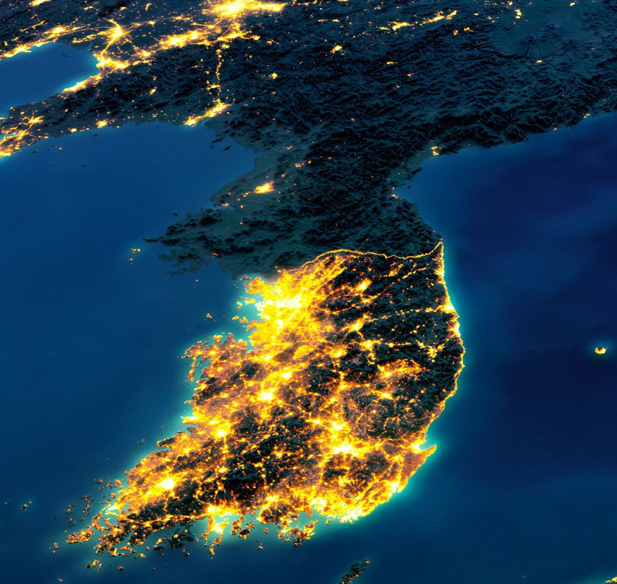

# The experimental ideal and its limits 🌟

## Why we should think about observational studies with RCTs in mind

- As you already know by now, RCTs have the highest internal validity among all research designs
- Since the treatment is isolated from other factors, we can be more confident about the causal effect
- But RCTs are not always feasible, and sometimes they are not ethical or practical
  - Example: Testing the effects of smoking on health outcomes, or of poverty on child development
- In these cases, we need to think creatively about how to estimate causal effects
- Yet, the logic of RCTs should guide our thinking in observational studies
  - Random assignment, control groups, pre-treatment equivalence, selection bias
- Natural and quasi-experiments are attempts to approximate the conditions of an RCT when true randomisation is not possible
- They are “second-best” in terms of internal validity compared to a well-executed RCT
- But they are often the best available or only feasible options
- Both RCTs and natural/quasi-experiments are driven by the same goal: to establish causal relationships
- The core logic of experiments, that is, of counterfactuals and potential outcomes, is the same
- Natural and quasi-experiments often have higher external validity than RCTs, as they are closer to real-world conditions
- But we only use observational data

# Natural experiments 🌍

## Definition

- Natural experiments are situations where the assignment of treatment is determined by nature or other factors outside the control of the researcher
- They are quasi-experimental designs that mimic the random assignment of treatments in experimental studies
- In many ways, they are the “gold standard” (so to speak!) for causal inference in observational studies
- There are mainly two kinds of natural experiments:
  - True natural experiments: When the treatment is indeed randomly assigned
  - As-if natural experiments: When the treatment is assigned by a procedure that we claim is as good as random for practical purposes
  - Examples of true natural experiments: Natural disasters, weather changes, lottery wins
  - Examples of as-if natural experiments: Eligibility rules, policy changes, roll-out of new technologies

## Example 01: Charter schools

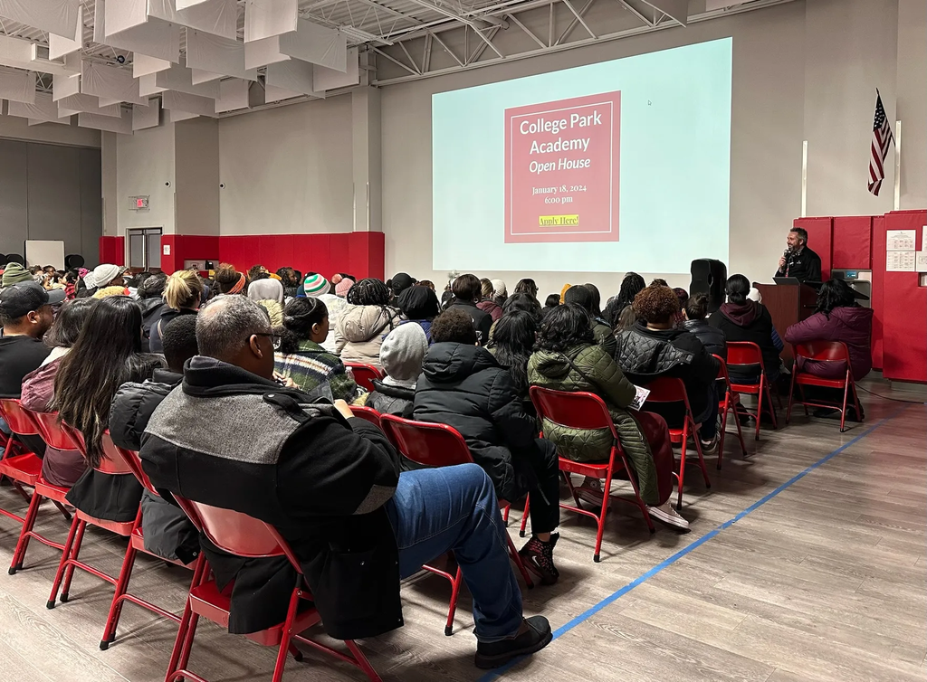

## Angrist et al. (2013)

### Explaining charter school effectiveness

[figure not shown]

Source: https://www.aeaweb.org/articles?id=10.1257/app.5.4.1

## Research question and challenge

- Research question: What is the *causal effect* of attending charter schools in Massachusetts on student test scores?
- The challenge: Students who choose to attend charter schools are likely to be different from those who don’t
  - Maybe more motivated families, different prior academic preparation, etc.
  - This is selection bias!
- We need a way to isolate the causal effect of charter schools, not just correlation
- The clever idea: Many charter schools are oversubscribed and use lotteries to decide who gets in
- Instrumental Variable (IV) Approach: Use a lottery win as an instrument to estimate the causal effect of charter attendance.
- Lottery win $\rightarrow$ Charter Attendance $\rightarrow$ Test Scores
- Lottery win is related to charter attendance, but ideally *only* affects test scores through charter attendance.

## Estimation strategy

- Equation (1): Outcome equation (What we want to explain)

$Y_{igt} = \alpha_{2t} + \beta_{2g} + \sum_{j} \delta_{j} d_{ij} + X_{i}' \theta + \tau S_{igt} + \epsilon_{igt}$

- $Y_{igt}$: Test score for student *i*, grade *g*, year *t*
- $S_{igt}$: Years spent in charter school (our treatment)
- $\tau$: Causal effect of charter attendance (what we want to find!)
- Lots of control variables (year ($\alpha_{2t}$) and grade ($\beta_{2g}$) fixed effects, dummies for combinations of charter school lotteries ($d_{ij}$), demographic characteristics ($X_i$), etc.) to account for other factors
- Equation (2): First Stage (How the lottery affects attendance)

$S_{igt} = \alpha_{1t} + \beta_{1g} + \sum_{j} \kappa_{ij} d_{ij} + X_{i}' \mu + \pi Z_{i} + \eta_{igt}$

- $Z_i$: Dummy variable = 1 if student *i* won the charter lottery (our instrument)
- $\pi$: Effect of lottery win on charter attendance (should be positive and strong)
- In Plain English:
1. **First Stage:** Check if winning the lottery actually increases charter school attendance (it should!)
2. **Second Stage:** Use the *lottery win* (which is random) to predict charter school attendance, and then see how this *predicted* attendance affects test scores

## Results

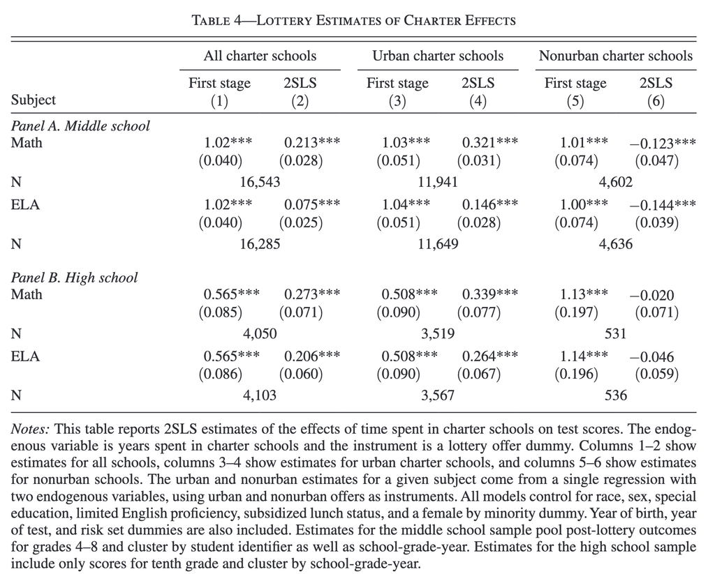

## Results

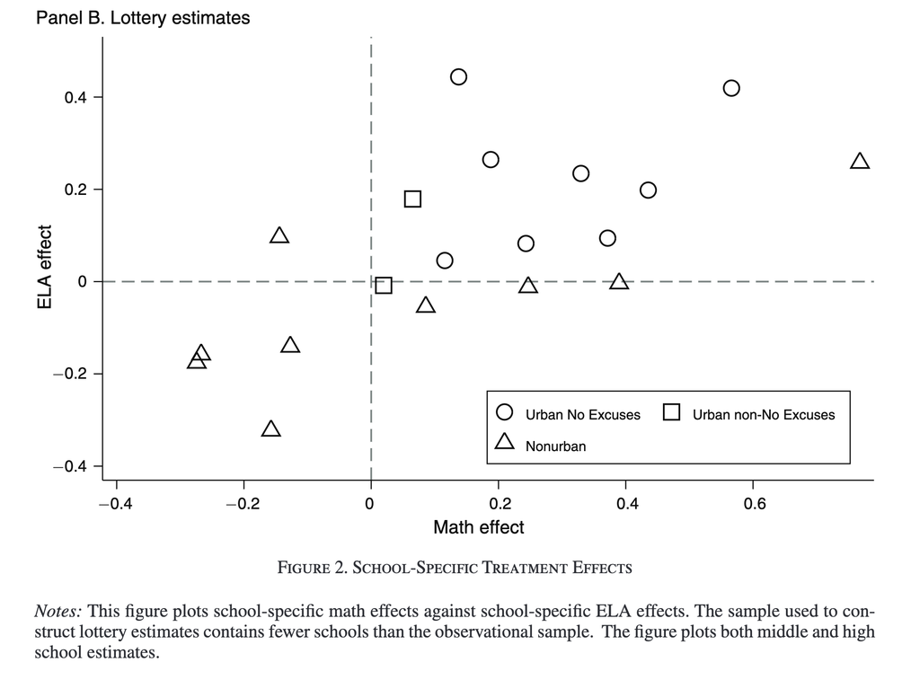

## “As-If” randomness: The core assumption of natural experiments

- The validity of most natural/quasi-experiments hinges on the assumption of “as-if” randomness
- We need to argue for the plausibility that the natural assignment mechanism is exogenous
  - Independent of other factors that influence the outcome
- Consider:
  - Is the “natural” assignment process truly independent of confounding variables?
  - Could individuals or groups have influenced the “assignment” to treatment or control?
  - Is there evidence of pre-existing differences between the groups “naturally” assigned to different conditions?
- Requires careful justification and scrutiny of the assignment process
- Not always perfect randomness, but sufficient approximation for causal inference in many cases

## Example 02: Ferwerda and Miller (2014)

### Political Devolution and Resistance to Foreign Rule: A Natural Experiment

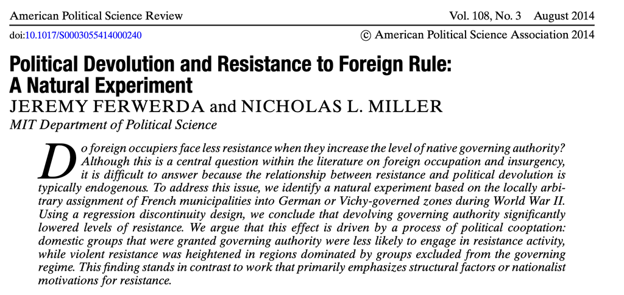

## Theory and “as-if” randomness

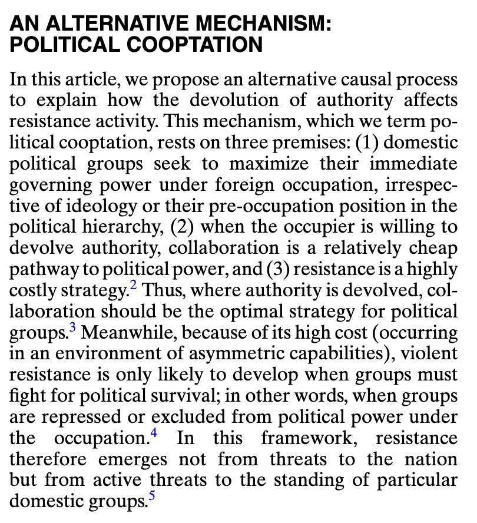

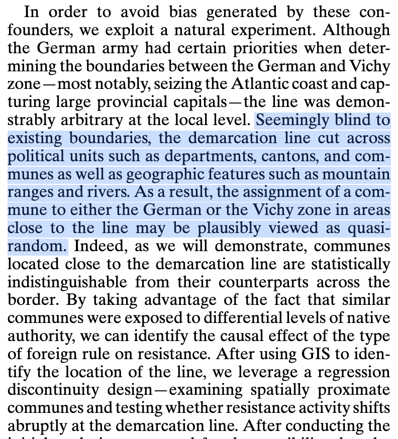

## Results

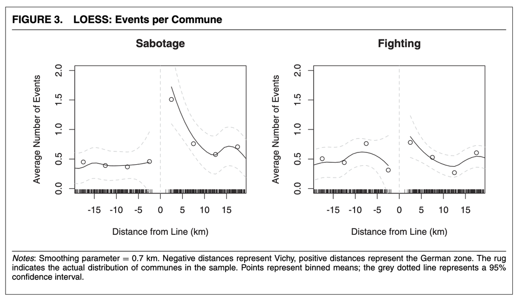

## Criticism of the natural experiment approach

### Kocher and Monteiro (2016)

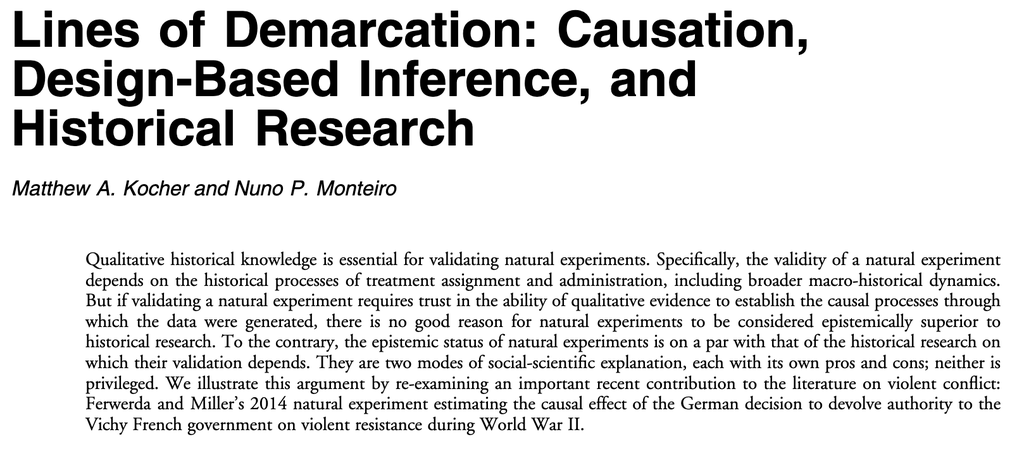

Source: https://doi.org/10.1017/S1537592716002863

## Kocher and Monteiro (2016)

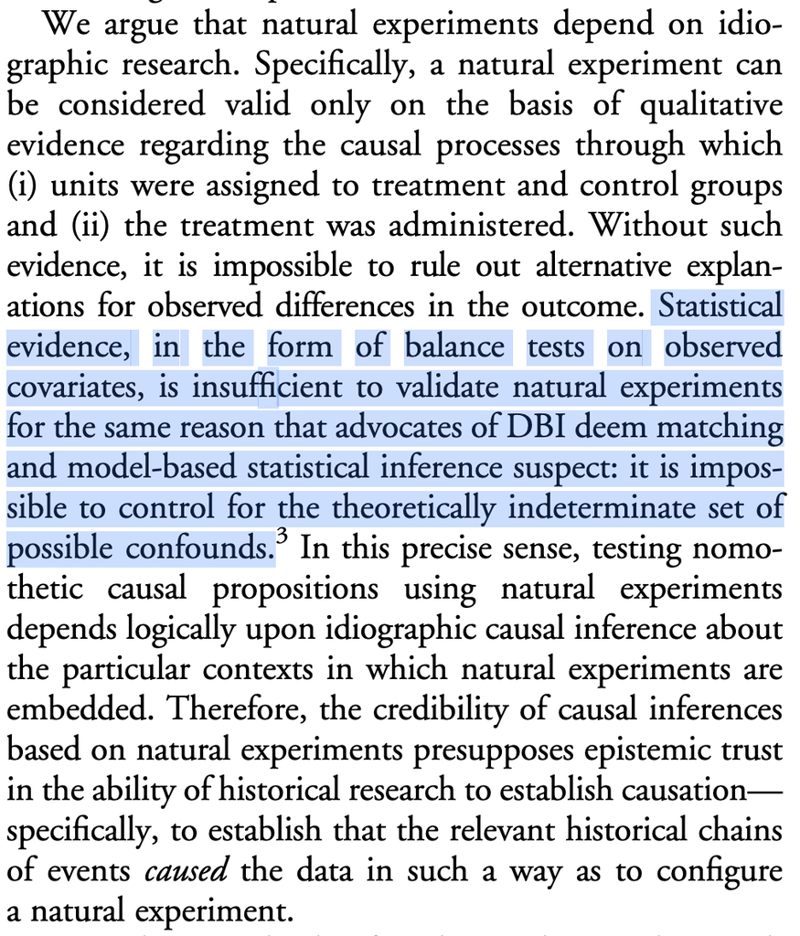

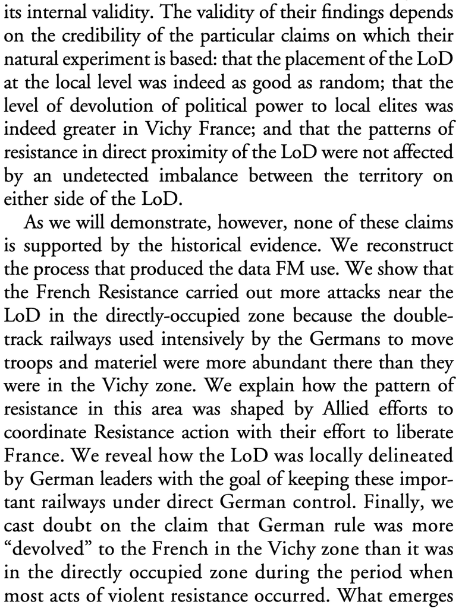

# Quasi-experiments 📊

## Quasi-experiments: A broader toolkit for approximation

- Quasi-experiments encompass a wider range of designs that lack full random assignment by the researcher
- Often involve some researcher manipulation of the research design, but not direct treatment randomisation
- Includes natural experiments as a subset, but also encompasses designs where researchers actively construct comparison groups
- Key feature: strategic use of design and statistical techniques to address confounding and selection bias
- Examples of Quasi-Experimental Designs (we also use them to analyse natural experiments!):
  - Regression Discontinuity Design (RDD)
  - Difference-in-Differences (DID)
  - Instrumental Variables (IV)
  - Matching Methods

## Regression discontinuity design (RDD)

- RDD exploits sharp or fuzzy discontinuities in treatment assignment based on a threshold or cutoff score
- Units are assigned to treatment or control based on whether they fall above or below a specific cutoff point on a continuous assignment variable (running variable)
- Compares units just above the threshold to units just below
  - For the linear case, $Y = \beta_{0} + \beta_{1}X + \beta_{2}(X > X_{0}) + \epsilon$
- Logic: Units very close to the cutoff are likely to be very similar in all other respects, except for treatment status
- Cutoff creates a local “as-if” randomisation around the threshold
- RDD estimates the treatment effect at the discontinuity point
- Key Assumption: Continuity
  - Potential outcomes are continuous functions of the assignment variable at the cutoff
  - No other discontinuous changes at the cutoff point besides the treatment

## RDD: Visualising the discontinuity

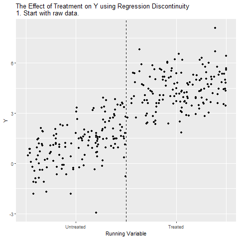

Source: [Nick Huntington-Klein](https://www.nickchk.com/causalgraphs.html)

- X-axis: Assignment/running variable
- Y-axis: Outcome variable
- Vertical dashed line: Cutoff threshold
- Treatment assigned for D >= Cutoff
- Continuity assumption: Smooth relationship between X and Y, except for the treatment effect at the cutoff
- Fuzzy RDD: When treatment assignment is not perfectly determined by the cutoff (some non-compliance)
- Manipulation of assignment variable can invalidate RDD
- Local Average Treatment Effect (LATE): RDD estimates the effect for those near the cutoff
- Extrapolation beyond the cutoff is generally not recommended

## Example 03: Mignozzetti et al. (2024)

[figure not shown]

Source: [Mignozzetti, U., et al. (2024). Legislature size and welfare: Evidence from Brazil, American Journal of Political Science](https://doi.org/10.1111/ajps.12843)

## Mignozzetti et al. (2024)

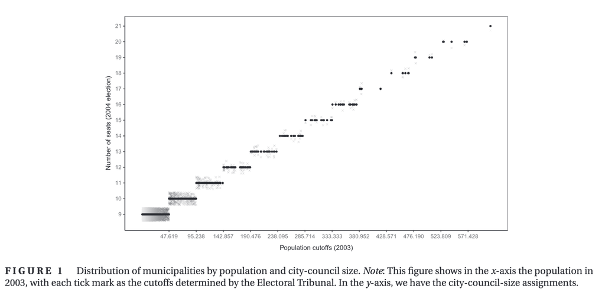

## Mignozzetti et al. (2024)

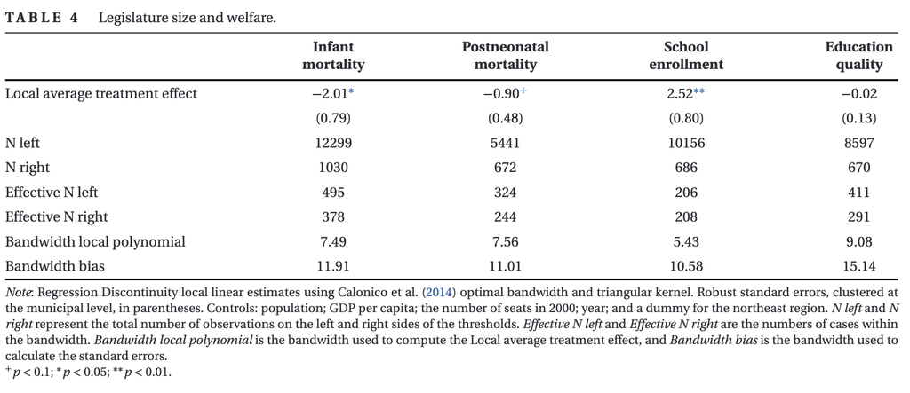

## Difference-in-Differences (DID): Leveraging policy changes

- Core Idea: Compare changes in outcomes over time between a treatment group and a control group
- Exploits naturally occurring events or policy changes that affect one group but not another
- Relies on comparing the difference in changes (hence “difference-in-differences”)
  - Change in outcome for treatment group - Change in outcome for control group
- Aims to isolate the treatment effect from:
  - Pre-existing differences between groups (captured by baseline differences)
  - Common trends over time (assumed to affect both groups similarly)
- Key Assumption: Parallel Trends
  - In the absence of treatment, the treatment and control groups would have followed similar trends in outcomes

## DID: Visualising the parallel trends

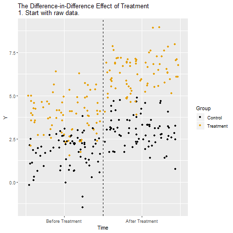

Source: [Nick Huntington-Klein](https://www.nickchk.com/causalgraphs.html)

- Equation: $Y_{it} = \alpha + \beta T_{i} + \gamma D_{t} + \delta (T_{i} \times D_{t}) + \epsilon_{it}$
  - $Y_{it}$: Outcome for unit *i* at time *t*
  - $T_{i}$: Treatment indicator (1 if treated, 0 otherwise)
  - $D_{t}$: Time indicator (1 if post-treatment, 0 otherwise)
  - $\delta$: DID estimator (difference-in-differences)
- Many extensions to the basic DID design:
  - Multiple time periods
  - Multiple treatment groups
  - Difference-in-Difference-in-Differences (DDD)
  - Synthetic Control Methods

## Example 04: Card and Krueger (1994)

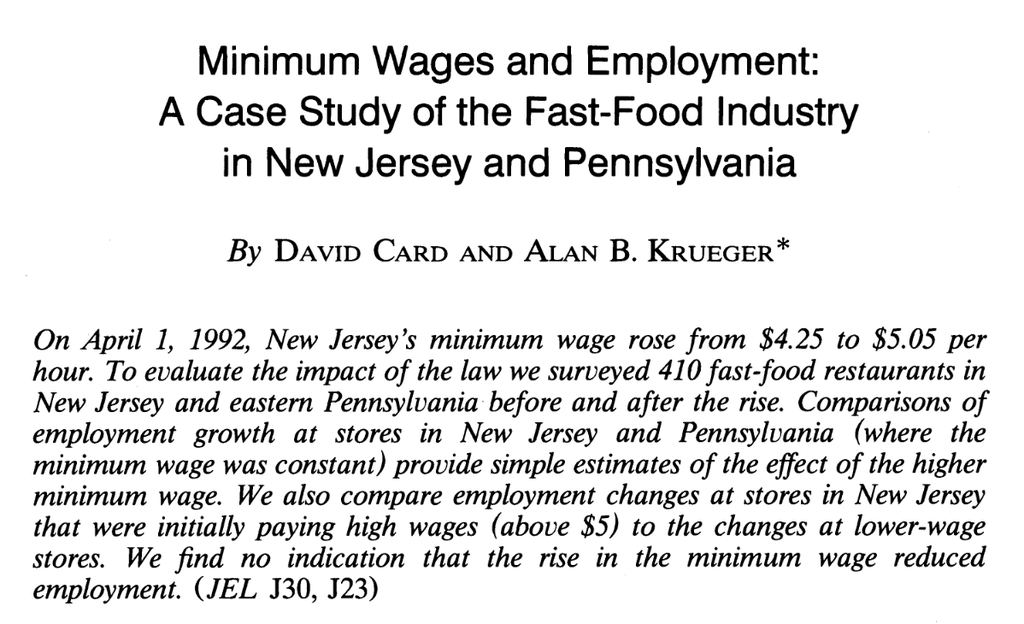

Source: [Card, D., & Krueger, A. B. (1994). Minimum Wages and Employment: A Case Study of the Fast-Food Industry in New Jersey and Pennsylvania. The American Economic Review, 84(4), 772-793.](https://www.mattblackwell.org/files/teaching/CarKru94.pdf)

## Card and Krueger (1994)

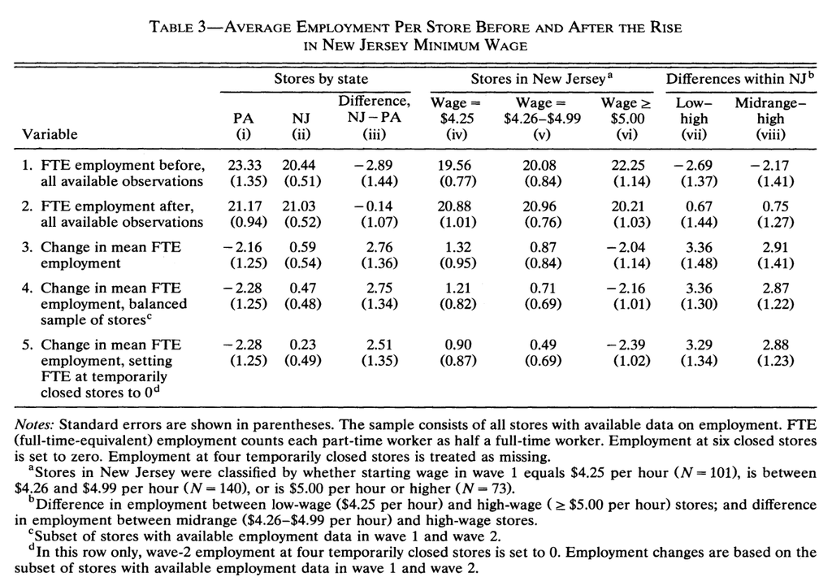

# Threats to validity and mitigation strategies

## Major threats to validity in quasi-experiments

- Confounding (selection bias):
  - Pre-existing differences between treatment and control groups that are related to both treatment and outcome
  - Can bias estimates in any quasi-experimental design
- Violation of key assumptions:
  - Parallel trends assumption in DID may not hold
  - Continuity assumption in RDD may be violated
  - Instrument validity assumptions (relevance and exclusion) in IV may be questionable
  - Selection on observables assumption in Matching may be false
- Measurement error: Can attenuate or bias estimates in any design
- Spillover effects/interference: Treatment effects in one group can affect outcomes in the control group, violating stable unit treatment value assumption (SUTVA)
- Attrition and missing data: Differential attrition between treatment and control groups can introduce bias

## Strategies for strengthening validity

- Careful design choice: Select the most appropriate quasi-experimental design given the research question and context
- Robustness checks and sensitivity analyses:
  - Test the sensitivity of findings to violations of key assumptions
  - Conduct placebo tests, falsification tests, and alternative specifications
- Control variables: Include relevant covariates to control for observable confounding
- Assumption checks and justification:
  - Clearly state and justify the assumptions of the chosen design
  - Provide evidence to support the plausibility of assumptions (e.g., pre-treatment trends for DID, density tests for RDD, instrument relevance tests for IV)
- Triangulation: Use multiple methods and data sources to corroborate findings
- Transparency: Be transparent about design limitations and assumptions in reporting results

## Ethics beyond randomisation

- While quasi-experiments often arise from ethical constraints on randomisation, ethical considerations remain important
- Be transparent about the limitations of the design and assumptions being made
- Quasi-experimental findings may be more easily misinterpreted than RCT results - emphasize responsible communication
- Consequences: Consider potential unintended consequences of studying natural events or policy changes, especially if findings inform future interventions
- Maintain ethical standards in data collection, storage, and analysis, especially when using sensitive data
- Even in observational settings, consider ethical guidelines for data collection and participant interaction
- Ethical review boards may still be involved in quasi-experimental research, especially if it involves human subjects data

# Conclusion 🌟

## Key takeaways

- Natural and quasi-experiments are valuable tools for causal inference when RCTs are not feasible
- Natural experiments use natural assignment mechanisms to mimic randomisation
- Quasi-experiments encompass a broader range of designs that lack full random assignment
- RDD, DID, IV, and Matching are common quasi-experimental designs
- Validity threats in quasi-experiments include confounding, assumption violations, measurement error, and attrition
- Strategies for strengthening validity include careful design choice, robustness checks, control variables, assumption checks, triangulation, and transparency
- Ethical considerations remain important in quasi-experimental research

[figure not shown]

Source: https://doi.org/10.1017/CBO9781139084444